# Regression methods - Accidents

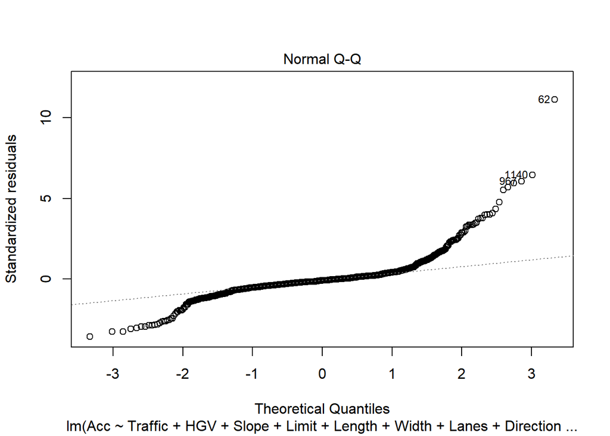

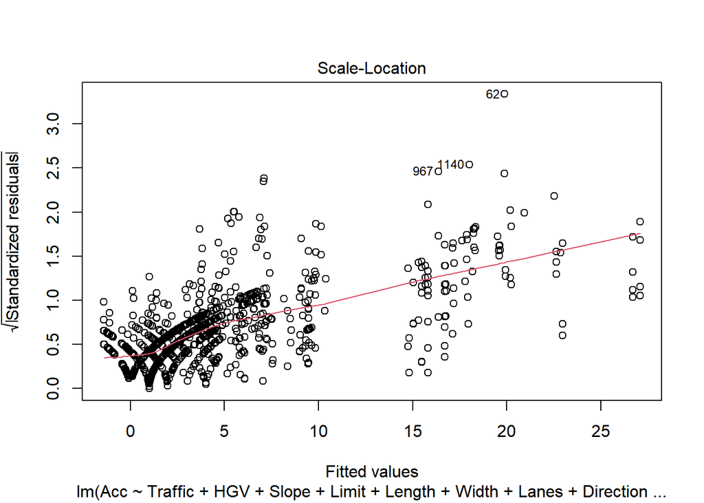

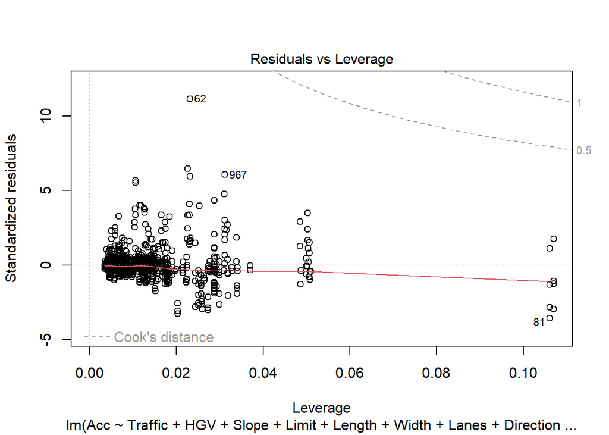

Without the categorical variables

```
##
## Call:
## lm(formula = Acc ~ Traffic + HGV + Slope + Limit + Length + Width +
##     Lanes, data = Accidents)
##
## Residuals:
##     Min      1Q  Median      3Q     Max
## -19.793  -2.506  -0.776   1.096  72.770
##
## Coefficients:
##               Estimate Std. Error t value Pr(>|t|)
## (Intercept)  1.616e+01  3.760e+00   4.297 1.88e-05 ***
## Traffic      2.001e-07  1.744e-08  11.469  < 2e-16 ***
## HGV         -6.457e+00  2.642e+00  -2.444  0.01467 *
## Slope       -1.284e+01  7.241e+00  -1.773  0.07653 .
## Limit       -5.911e-02  1.208e-02  -4.893 1.14e-06 ***
## Length       3.307e-04  1.042e-04   3.174  0.00154 **
## Width       -3.701e+00  1.159e+00  -3.193  0.00145 **
## Lanes        1.928e+00  3.056e-01   6.310 3.97e-10 ***
## ---
## Signif. codes:  0 '***' 0.001 '**' 0.01 '*' 0.05 '.' 0.1 ' ' 1
##
## Residual standard error: 6.319 on 1152 degrees of freedom
## Multiple R-squared:  0.3085, Adjusted R-squared:  0.3043
## F-statistic: 73.41 on 7 and 1152 DF,  p-value: < 2.2e-16
```

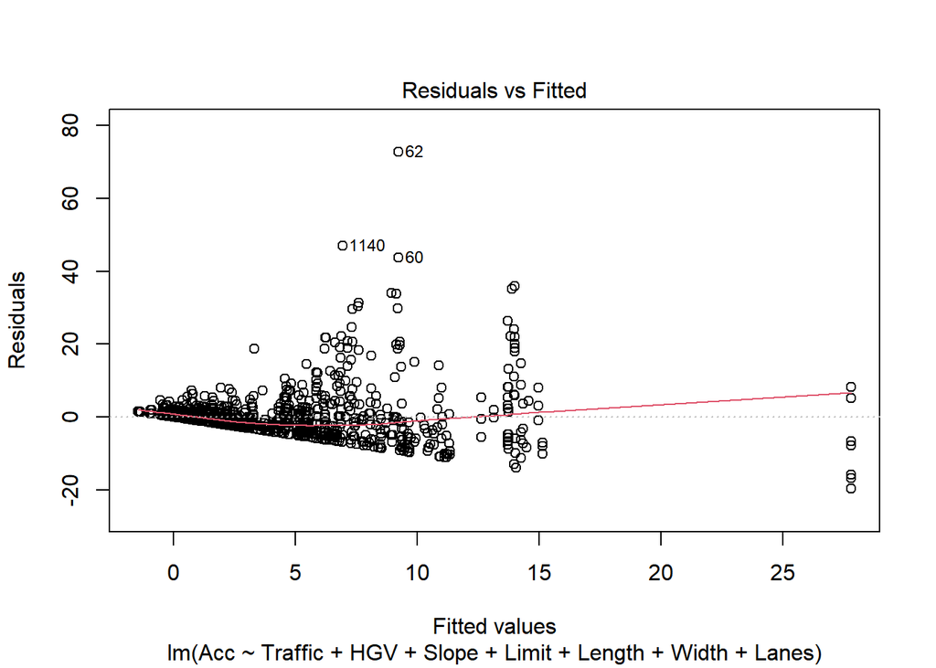

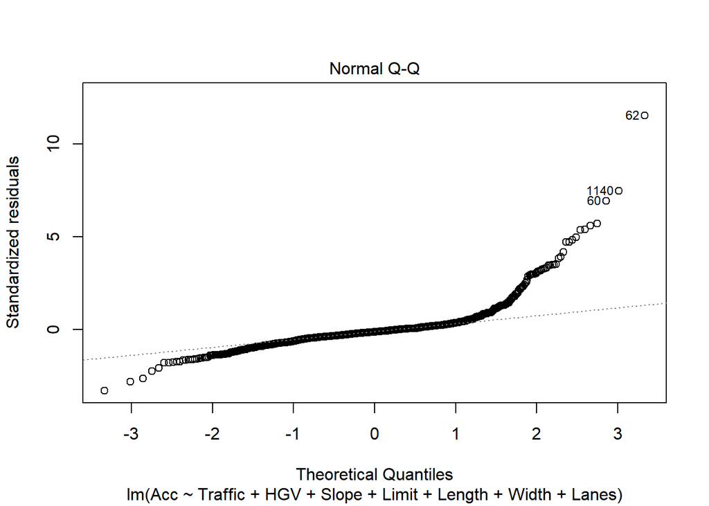

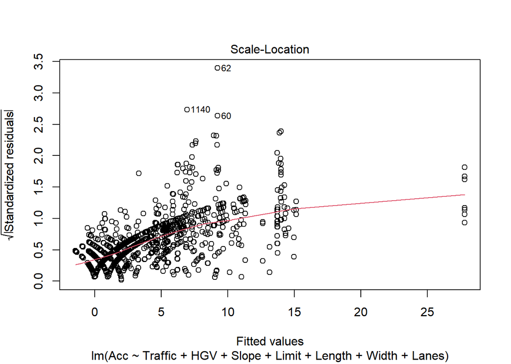

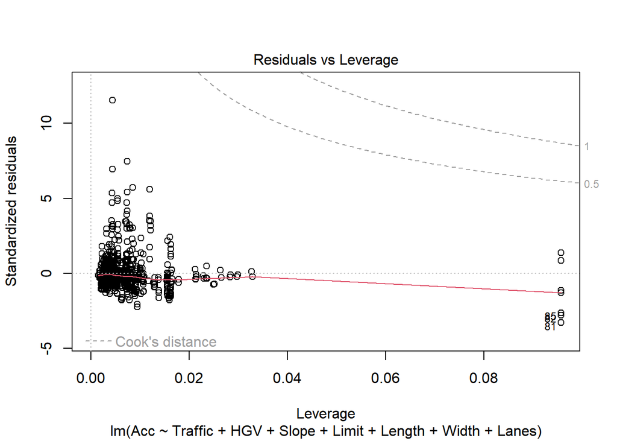

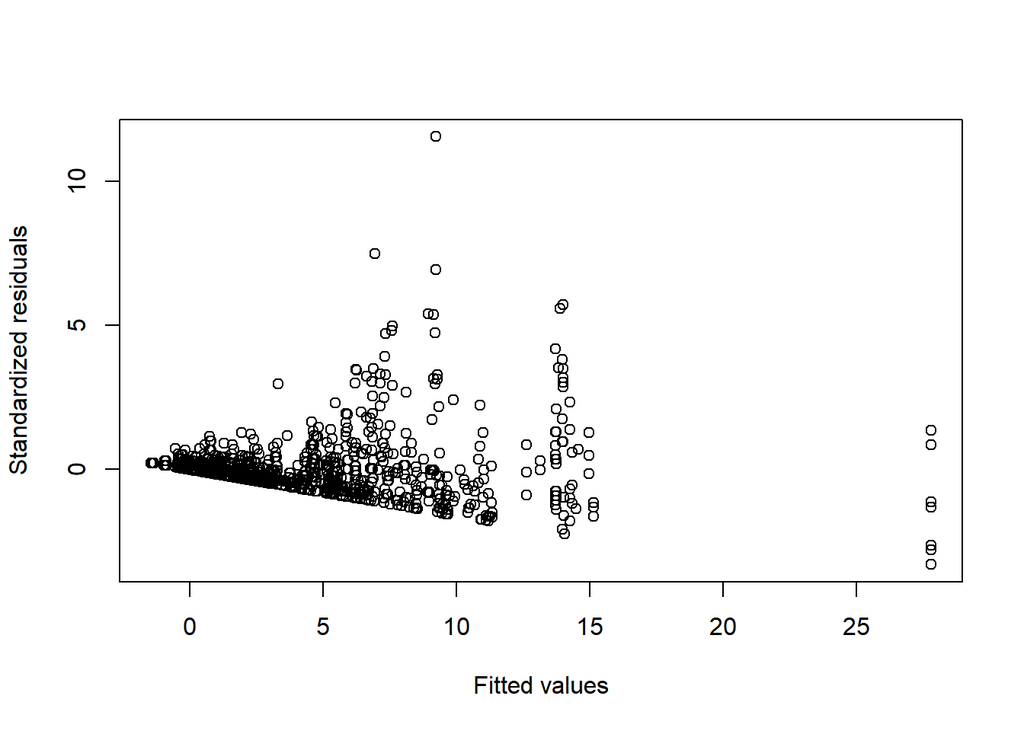

Standardised residuals

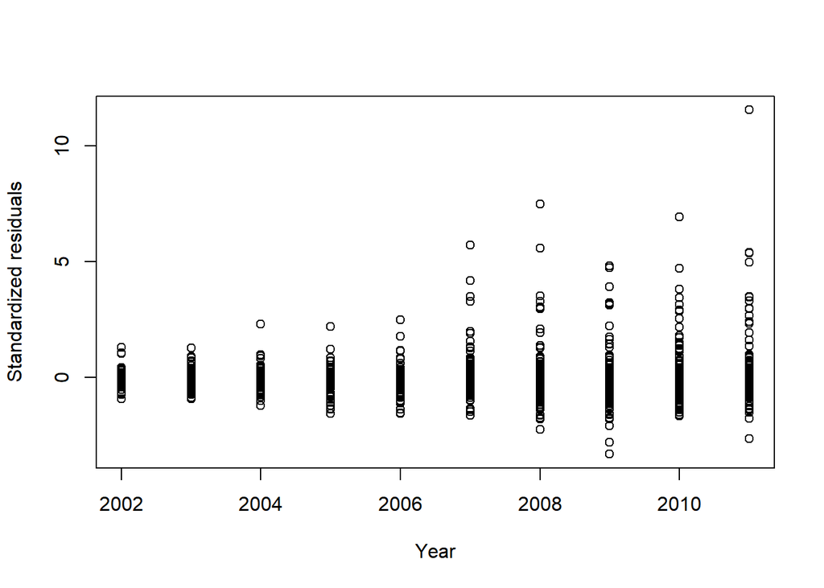

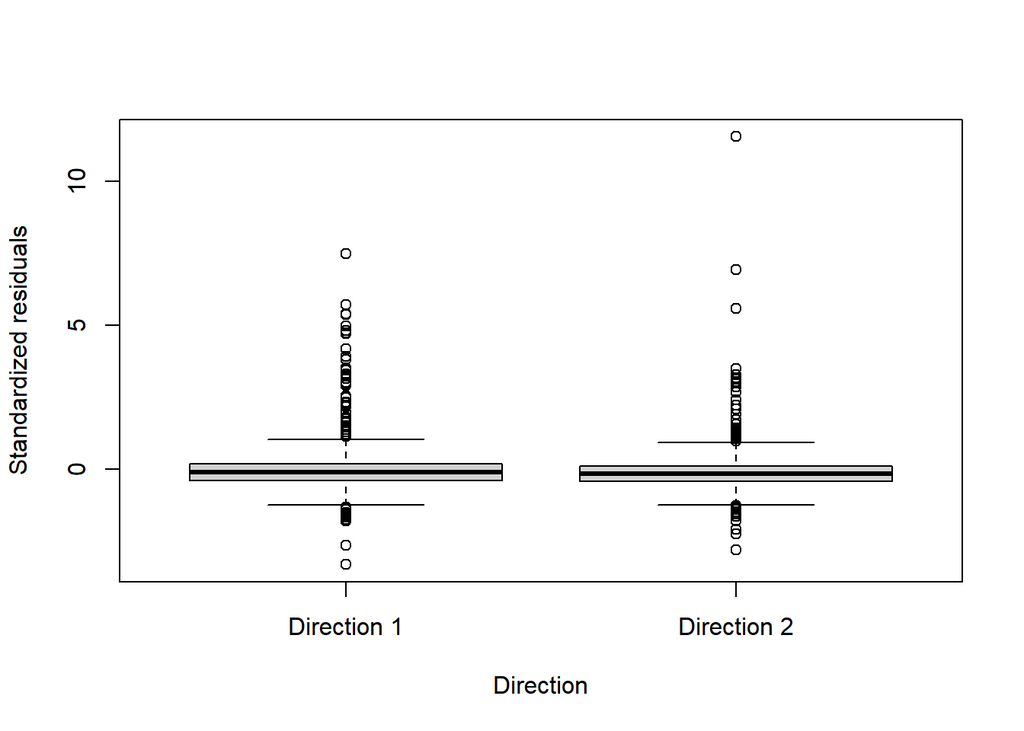

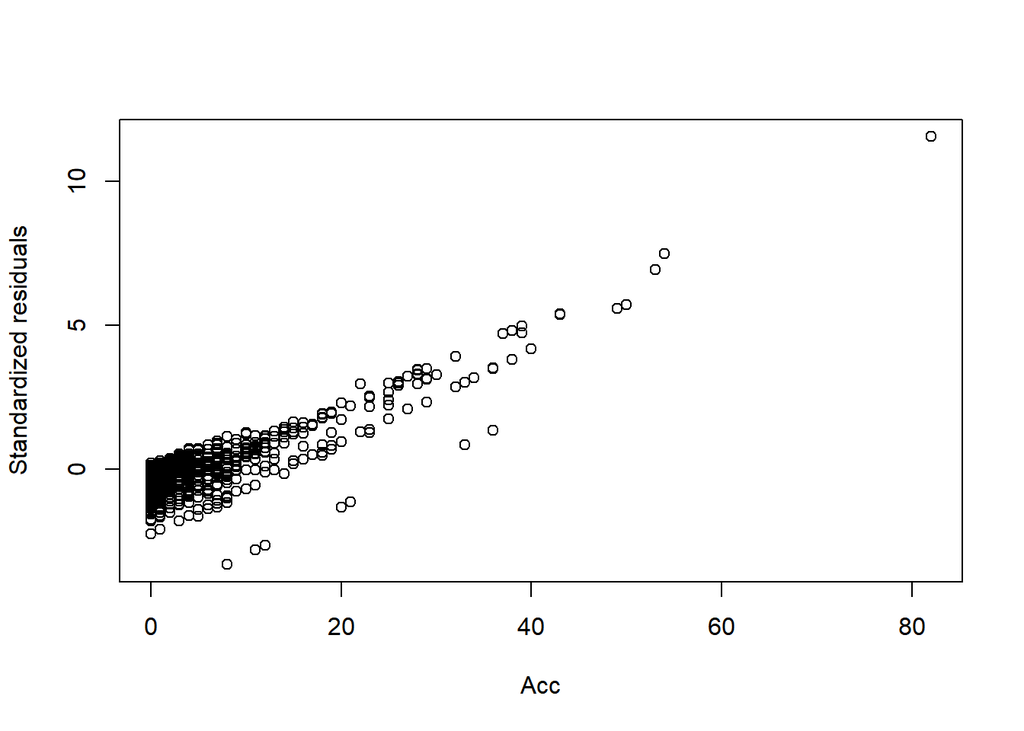

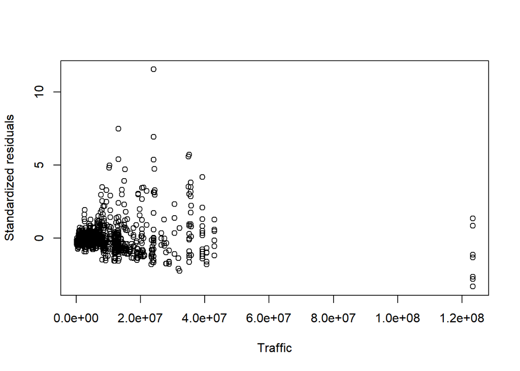

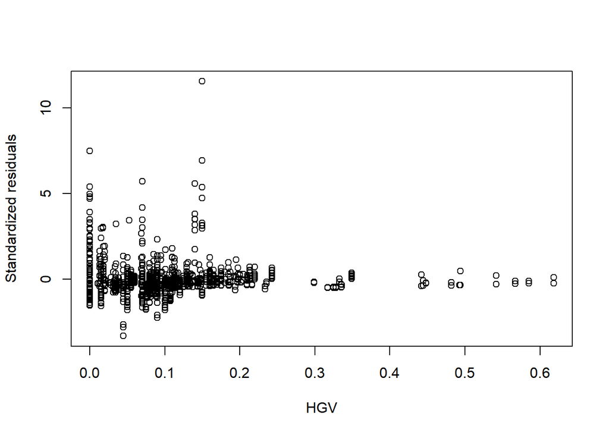

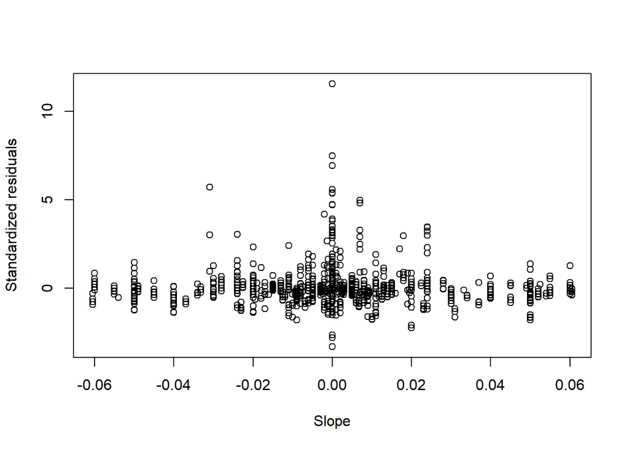

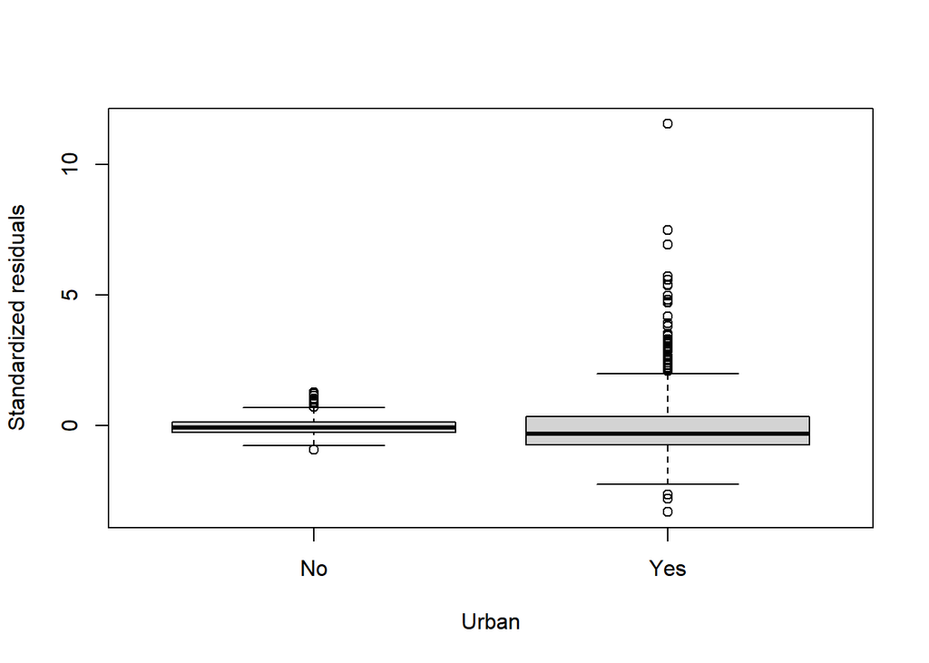

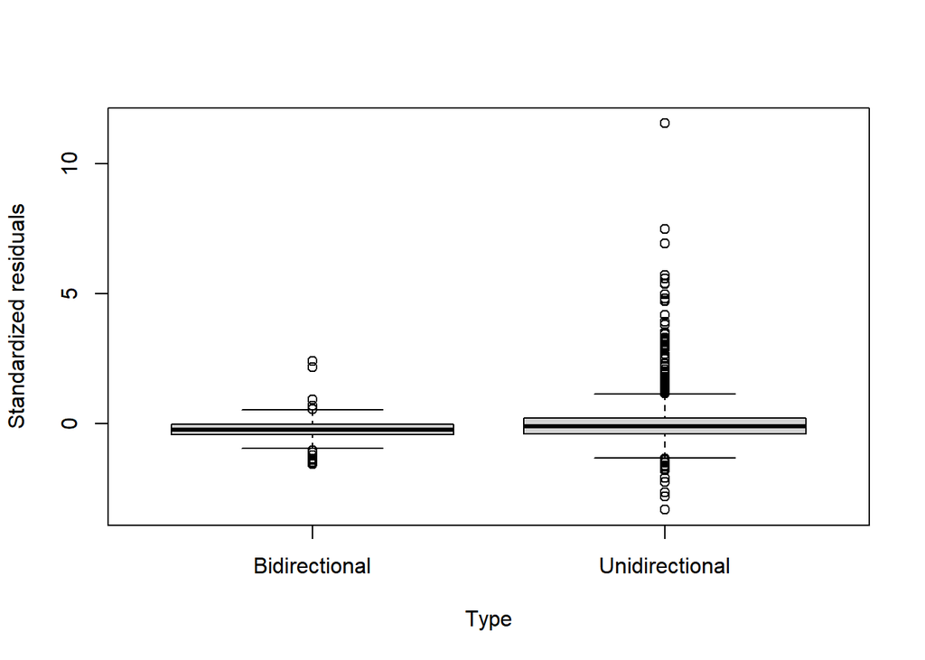

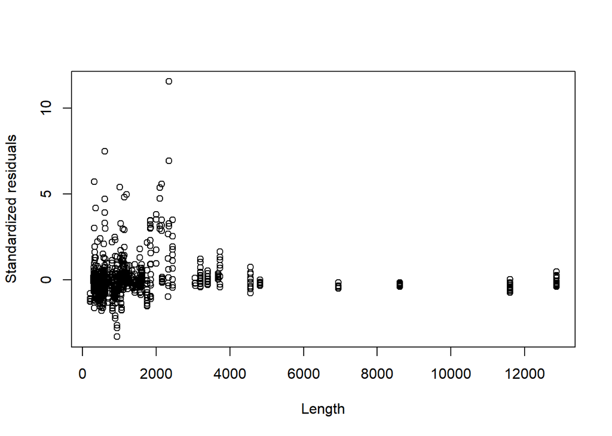

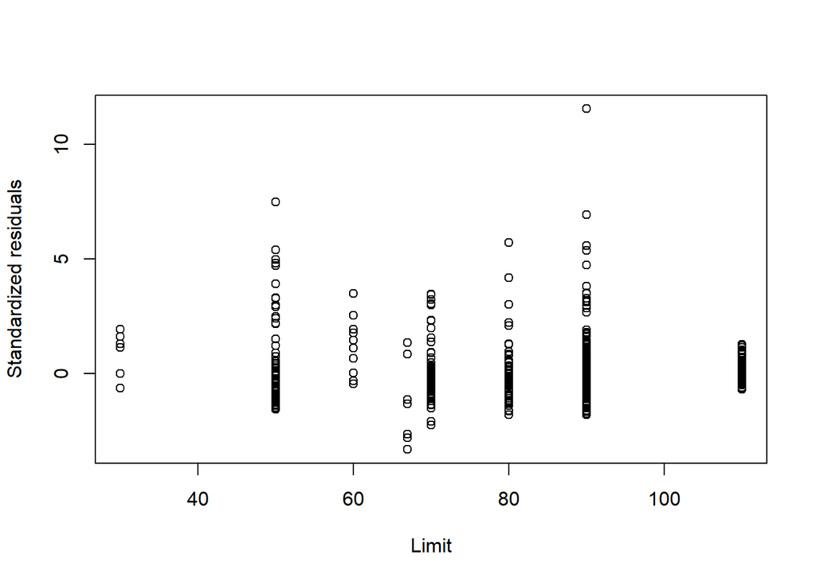

[figure not shown]

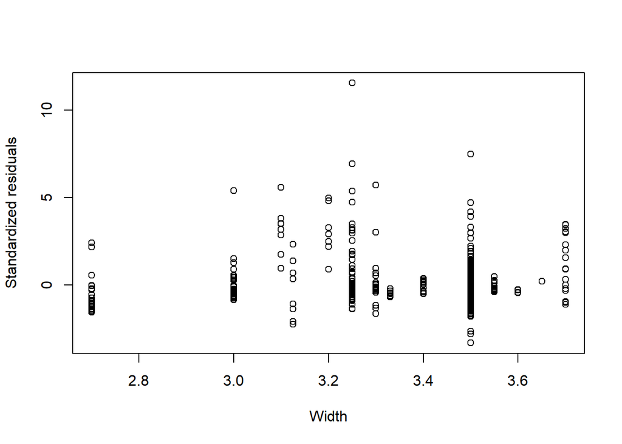

[3 more figures not shown]

Without slope and HGV

```
##
## Call:
## lm(formula = Acc ~ Traffic + Limit + Length + Width + Lanes,
##     data = Accidents)
##
## Residuals:
##     Min      1Q  Median      3Q     Max
## -20.240  -2.783  -0.705   0.897  72.505
##
## Coefficients:
##               Estimate Std. Error t value Pr(>|t|)
## (Intercept)  1.865e+01  3.663e+00   5.092 4.13e-07 ***
## Traffic      2.056e-07  1.740e-08  11.818  < 2e-16 ***
## Limit       -6.706e-02  1.162e-02  -5.769 1.02e-08 ***
## Length       1.861e-04  8.762e-05   2.124  0.03391 *
## Width       -4.332e+00  1.139e+00  -3.803  0.00015 ***
## Lanes        1.851e+00  3.031e-01   6.107 1.39e-09 ***
## ---
## Signif. codes:  0 '***' 0.001 '**' 0.01 '*' 0.05 '.' 0.1 ' ' 1
##
## Residual standard error: 6.34 on 1154 degrees of freedom
## Multiple R-squared:  0.3027, Adjusted R-squared:  0.2997
## F-statistic: 100.2 on 5 and 1154 DF,  p-value: < 2.2e-16
```

Log transformation

```
##
## Call:
## lm(formula = log(Acc + 1) ~ Traffic + Limit + Length + Width +
##     Lanes, data = Accidents)
##
## Residuals:
##      Min       1Q   Median       3Q      Max
## -2.59733 -0.59269 -0.03774  0.52434  2.61270
##
## Coefficients:
##               Estimate Std. Error t value Pr(>|t|)
## (Intercept)  3.009e+00  4.623e-01   6.508 1.13e-10 ***
## Traffic      2.530e-08  2.196e-09  11.524  < 2e-16 ***
## Limit       -9.576e-03  1.467e-03  -6.528 9.94e-11 ***
## Length       1.904e-05  1.106e-05   1.722   0.0853 .
## Width       -6.164e-01  1.438e-01  -4.288 1.95e-05 ***
## Lanes        3.390e-01  3.825e-02   8.863  < 2e-16 ***
## ---
## Signif. codes:  0 '***' 0.001 '**' 0.01 '*' 0.05 '.' 0.1 ' ' 1
##
## Residual standard error: 0.8 on 1154 degrees of freedom
## Multiple R-squared:  0.3533, Adjusted R-squared:  0.3505
## F-statistic: 126.1 on 5 and 1154 DF,  p-value: < 2.2e-16
```

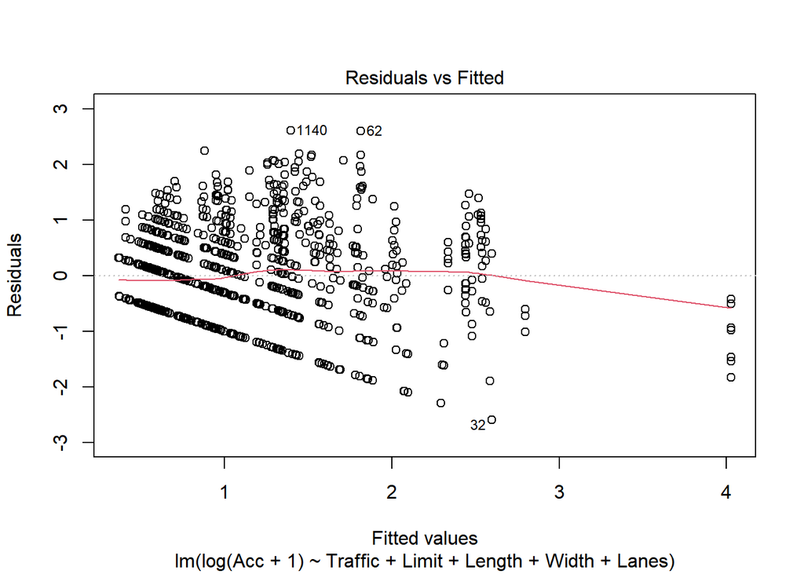

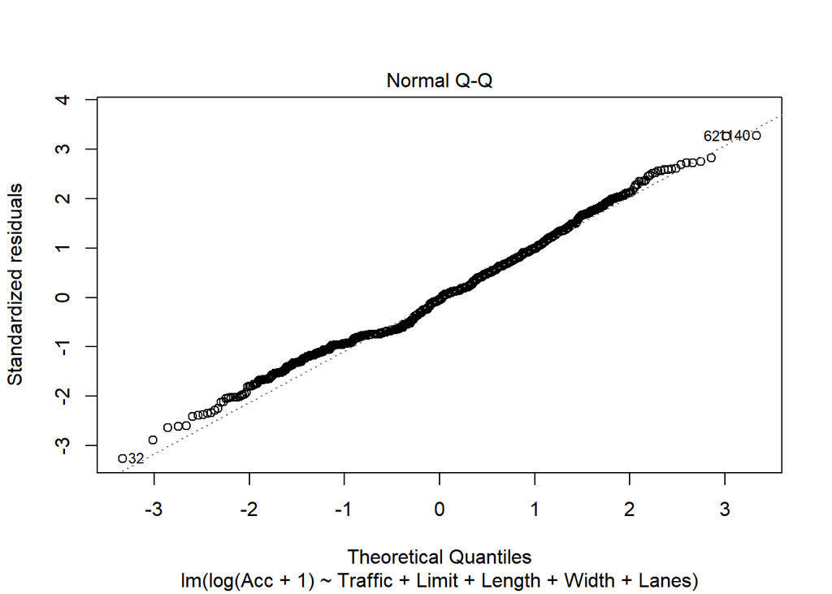

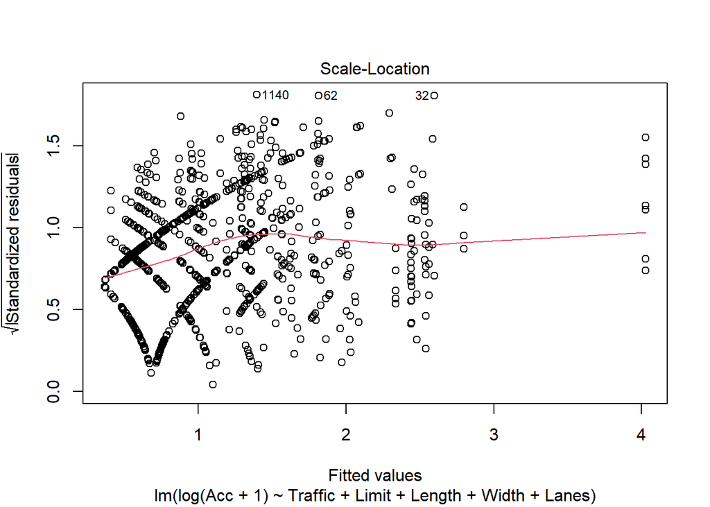

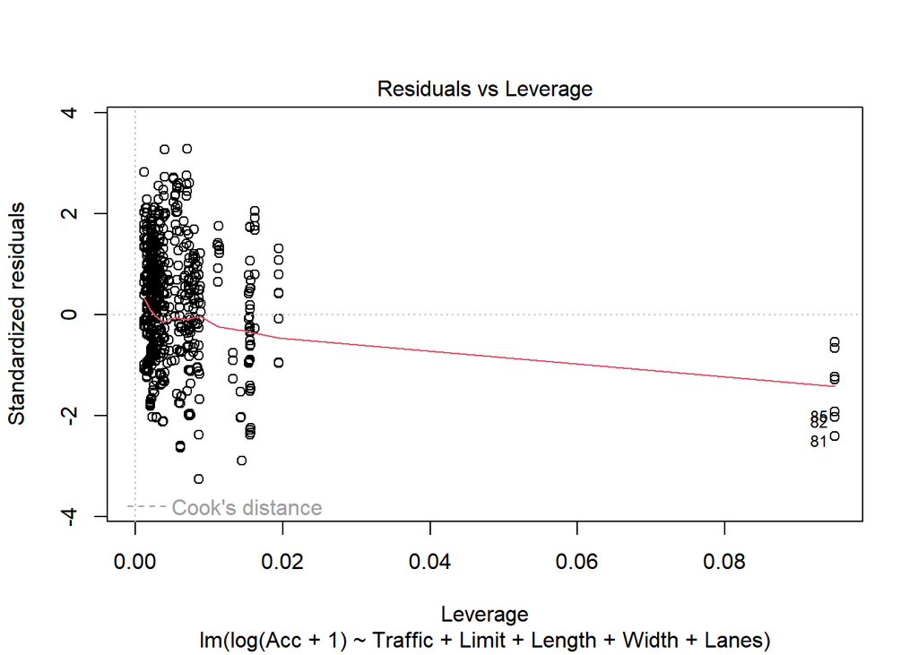

Without length

```
##
## Call:
## lm(formula = log(Acc + 1) ~ Traffic + Limit + Width + Lanes,
##     data = Accidents)
##
## Residuals:
##     Min      1Q  Median      3Q     Max
## -2.5672 -0.5969  0.0015  0.5168  2.6431
##
## Coefficients:
##               Estimate Std. Error t value Pr(>|t|)
## (Intercept)  3.002e+00  4.627e-01   6.489 1.28e-10 ***
## Traffic      2.522e-08  2.197e-09  11.477  < 2e-16 ***
## Limit       -1.010e-02  1.436e-03  -7.031 3.50e-12 ***
## Width       -5.771e-01  1.421e-01  -4.063 5.18e-05 ***
## Lanes        3.163e-01  3.595e-02   8.800  < 2e-16 ***
## ---
## Signif. codes:  0 '***' 0.001 '**' 0.01 '*' 0.05 '.' 0.1 ' ' 1
##
## Residual standard error: 0.8007 on 1155 degrees of freedom
## Multiple R-squared:  0.3517, Adjusted R-squared:  0.3494
## F-statistic: 156.6 on 4 and 1155 DF,  p-value: < 2.2e-16
```

## Mixed models

The idea here would be to consider random and fixed effects :  
*random : tunnel, company, year,* fixed : Traffic, Lanes, Width, Type, Length, Limit, Slope

Trying to cluster by tunnel : the idea is that the tunnels have random effects whereas the Traffic and Lanes are fixed effects. I don’t really understand the models below, I don’t know how to interpret.

```r
library('lme4')
summary(lmer(Acc ~ log(Traffic) + Lanes + Width + Type + log(Length) + Limit + Slope + (1 | Tunnel), data = Accidents))
```

```
## Linear mixed model fit by REML ['lmerMod']
## Formula: Acc ~ log(Traffic) + Lanes + Width + Type + log(Length) + Limit +
##     Slope + (1 | Tunnel)
##    Data: Accidents
##
## REML criterion at convergence: 6870.6
##
## Scaled residuals:
##     Min      1Q  Median      3Q     Max
## -5.4565 -0.2674 -0.0657  0.2140 10.0753
##
## Random effects:
##  Groups   Name        Variance Std.Dev.
##  Tunnel   (Intercept) 35.38    5.948
##  Residual             17.31    4.161
## Number of obs: 1160, groups:  Tunnel, 92
##
## Fixed effects:
##                     Estimate Std. Error t value
## (Intercept)        -21.56993   18.08524  -1.193
## log(Traffic)         2.82135    0.63478   4.445
## Lanes               -0.41333    0.52439  -0.788
## Width               -7.81888    3.81164  -2.051
## TypeUnidirectional   5.98731    2.11391   2.832
## log(Length)          2.29151    0.78023   2.937
## Limit               -0.11749    0.03709  -3.167
## Slope               -5.87324    5.20885  -1.128
##
## Correlation of Fixed Effects:
##             (Intr) lg(Tr) Lanes  Width  TypUnd lg(Ln) Limit
## log(Traffc) -0.717
## Lanes        0.114 -0.318
## Width       -0.750  0.239  0.005
## TypUndrctnl  0.264 -0.389 -0.131 -0.276
## log(Length) -0.318  0.093  0.055 -0.086  0.330
## Limit       -0.025  0.151 -0.072 -0.283 -0.203 -0.015
## Slope       -0.031  0.111 -0.349 -0.003  0.038 -0.037  0.018
```

```r
library('lme4')
summary(lmer(Acc ~ log(Traffic) + Lanes + Width + Type + log(Length) + Limit + Slope + (1 | Company), data = Accidents))
```

```
## Linear mixed model fit by REML ['lmerMod']
## Formula: Acc ~ log(Traffic) + Lanes + Width + Type + log(Length) + Limit +
##     Slope + (1 | Company)
##    Data: Accidents
##
## REML criterion at convergence: 7395.2
##
## Scaled residuals:
##     Min      1Q  Median      3Q     Max
## -2.8714 -0.3991 -0.0665  0.2340 11.2088
##
## Random effects:
##  Groups   Name        Variance Std.Dev.
##  Company  (Intercept) 13.52    3.677
##  Residual             32.73    5.721
## Number of obs: 1160, groups:  Company, 25
##
## Fixed effects:
##                     Estimate Std. Error t value
## (Intercept)        -47.14628    7.43760  -6.339
## log(Traffic)         2.46622    0.34467   7.155
## Lanes               -0.40348    0.43437  -0.929
## Width               -0.18873    1.43721  -0.131
## TypeUnidirectional   3.00495    0.83156   3.614
## log(Length)          2.20342    0.29648   7.432
## Limit               -0.02375    0.01759  -1.350
## Slope               -4.50943    6.67904  -0.675
##
## Correlation of Fixed Effects:
##             (Intr) lg(Tr) Lanes  Width  TypUnd lg(Ln) Limit
## log(Traffc) -0.685
## Lanes        0.045 -0.381
## Width       -0.690  0.099  0.188
## TypUndrctnl  0.418 -0.269 -0.338 -0.487
## log(Length) -0.146 -0.172  0.144 -0.079  0.318
## Limit       -0.242  0.146 -0.176 -0.005 -0.170 -0.052
## Slope       -0.007  0.092 -0.238 -0.059  0.077 -0.017  0.040
```

```r
summary( aov(Acc ~ Traffic/Tunnel, data=Accidents) )
```

```
##                  Df Sum Sq Mean Sq F value Pr(>F)
## Traffic           1  16047   16047  937.27 <2e-16 ***
## Traffic:Tunnel   91  32198     354   20.67 <2e-16 ***
## Residuals      1067  18268      17
## ---
## Signif. codes:  0 '***' 0.001 '**' 0.01 '*' 0.05 '.' 0.1 ' ' 1
```

```r
summary( aov(Acc ~ Traffic + Tunnel, data=Accidents) )
```

```
##               Df Sum Sq Mean Sq F value Pr(>F)
## Traffic        1  16047   16047  932.93 <2e-16 ***
## Tunnel        91  32113     353   20.52 <2e-16 ***
## Residuals   1067  18353      17
## ---
## Signif. codes:  0 '***' 0.001 '**' 0.01 '*' 0.05 '.' 0.1 ' ' 1
```

```r
summary( aov(Acc ~ Traffic/Company, data=Accidents) )
```

```
##                   Df Sum Sq Mean Sq F value Pr(>F)
## Traffic            1  16047   16047  508.04 <2e-16 ***
## Traffic:Company   24  14648     610   19.32 <2e-16 ***
## Residuals       1134  35818      32
## ---
## Signif. codes:  0 '***' 0.001 '**' 0.01 '*' 0.05 '.' 0.1 ' ' 1
```

## Fitting a Poisson model ?

The summary is quite excellent but the QQplot is skewed.

```
##
## Call:
## glm(formula = Acc ~ Lanes + Traffic, family = "poisson", data = Accidents)
##
## Deviance Residuals:
##     Min       1Q   Median       3Q      Max
## -5.7174  -2.1427  -1.2146   0.2407  16.1088
##
## Coefficients:
##              Estimate Std. Error z value Pr(>|z|)
## (Intercept) 4.367e-02  4.221e-02   1.035    0.301
## Lanes       4.512e-01  1.528e-02  29.526   <2e-16 ***
## Traffic     2.109e-08  5.230e-10  40.331   <2e-16 ***
## ---
## Signif. codes:  0 '***' 0.001 '**' 0.01 '*' 0.05 '.' 0.1 ' ' 1
##
## (Dispersion parameter for poisson family taken to be 1)
##
##     Null deviance: 9676.0  on 1159  degrees of freedom
## Residual deviance: 7099.6  on 1157  degrees of freedom
## AIC: 9578.8
##
## Number of Fisher Scoring iterations: 6
```

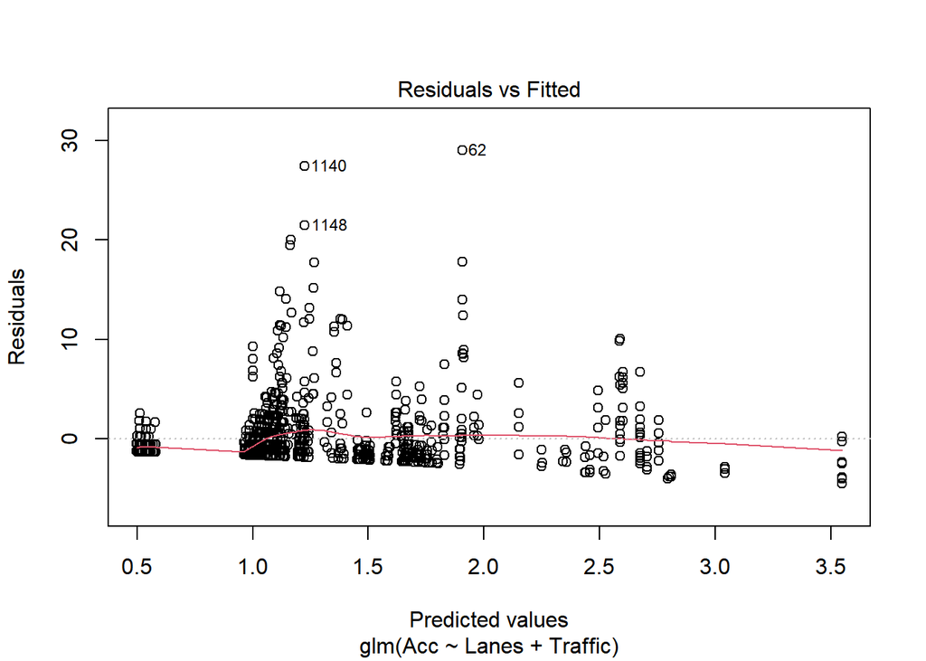

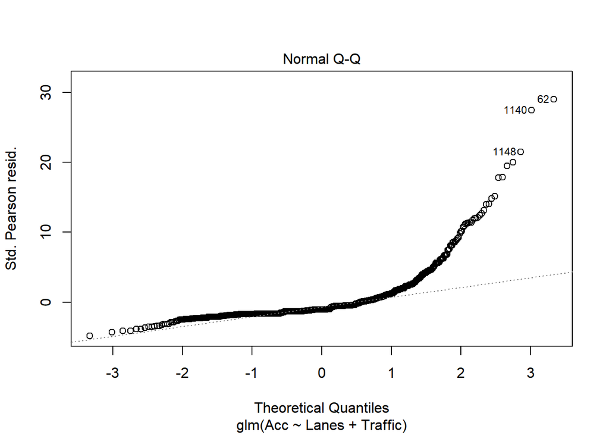

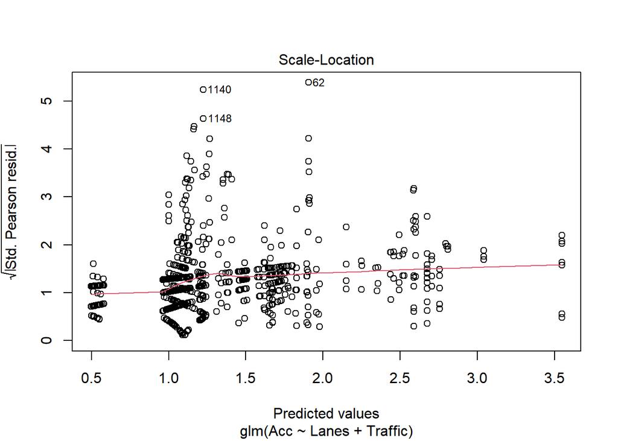

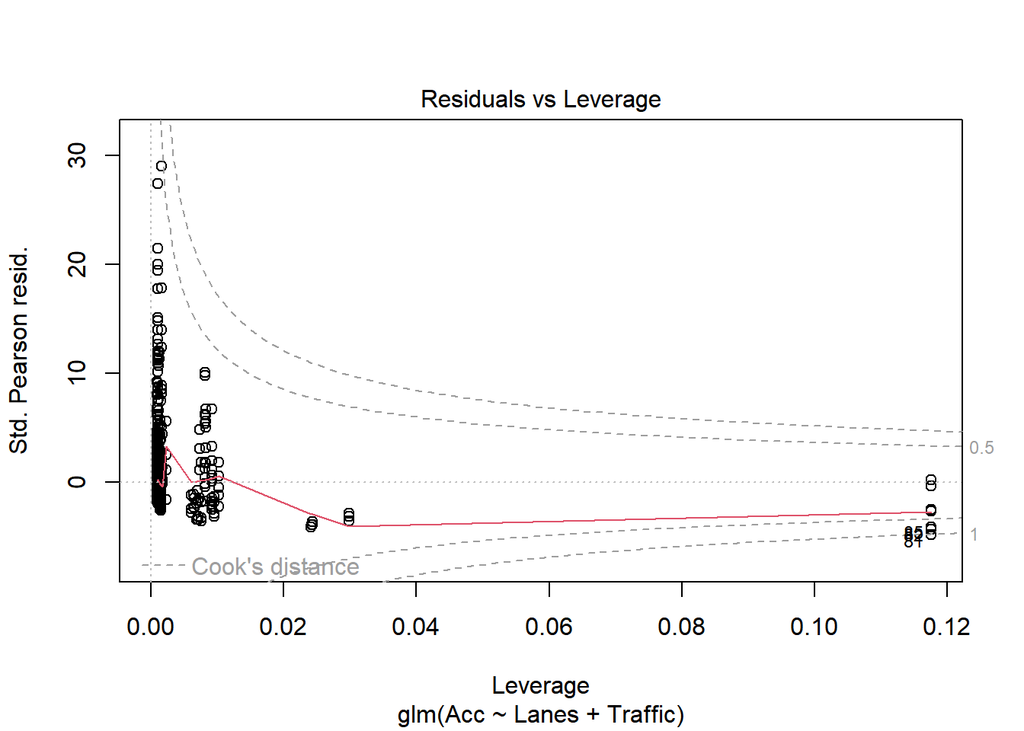

```
## [1] 9578.847
```

## Fitting an exponential model

The summary shows a clear effect of Traffic but Lanes is not significant. The QQplot shows skewed residuals.

```
##
## Call:
## glm(formula = (Acc + 1) ~ Lanes + Traffic, family = Gamma(link = "log"),
##     data = Accidents)
##
## Deviance Residuals:
##     Min       1Q   Median       3Q      Max
## -2.9710  -0.8435  -0.3891   0.1292   3.8722
##
## Coefficients:
##              Estimate Std. Error t value Pr(>|t|)
## (Intercept) 7.188e-01  9.864e-02   7.287 5.87e-13 ***
## Lanes       9.313e-02  4.844e-02   1.923   0.0548 .
## Traffic     5.432e-08  2.937e-09  18.495  < 2e-16 ***
## ---
## Signif. codes:  0 '***' 0.001 '**' 0.01 '*' 0.05 '.' 0.1 ' ' 1
##
## (Dispersion parameter for Gamma family taken to be 1.275766)
##
##     Null deviance: 1360.37  on 1159  degrees of freedom
## Residual deviance:  893.76  on 1157  degrees of freedom
## AIC: 5598
##
## Number of Fisher Scoring iterations: 25
```

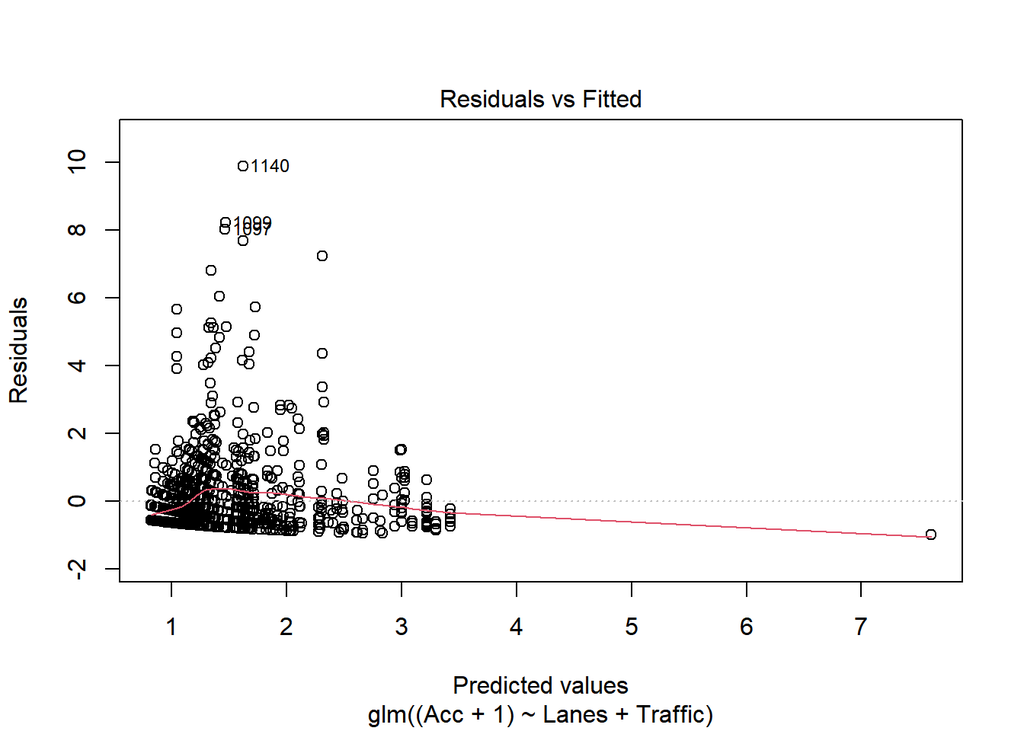

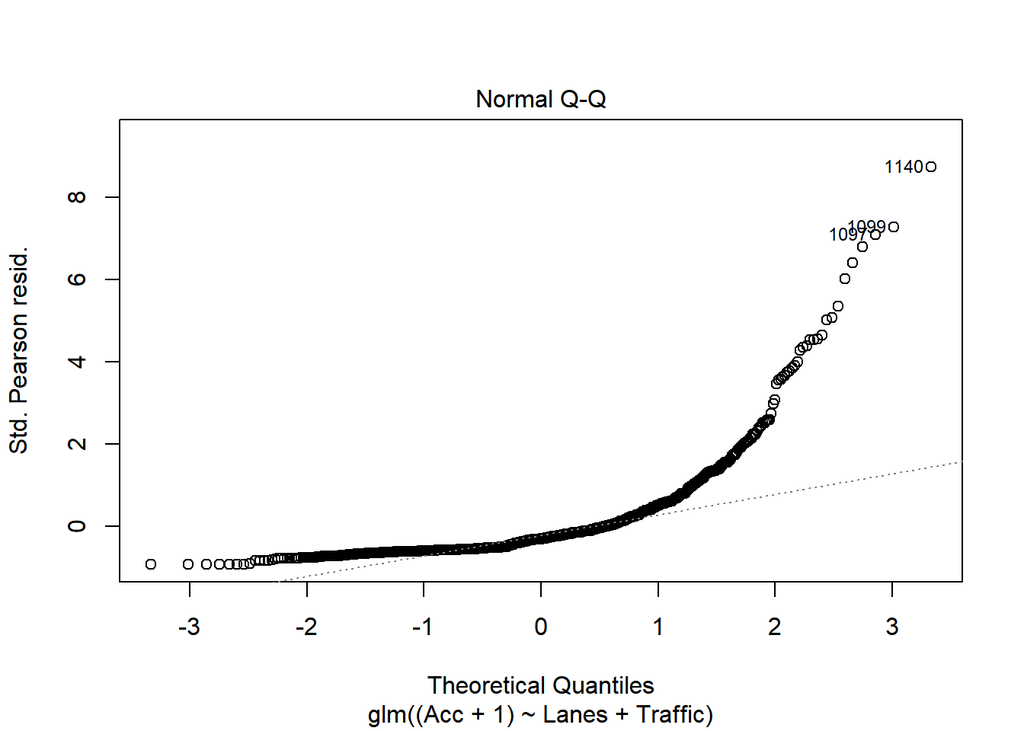

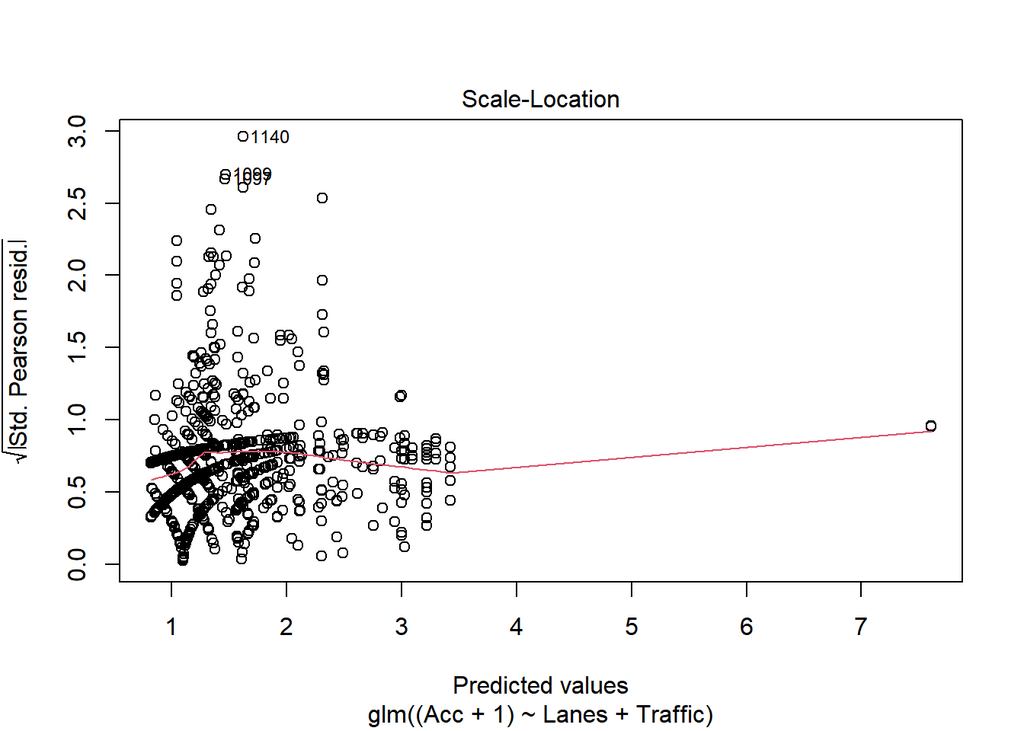

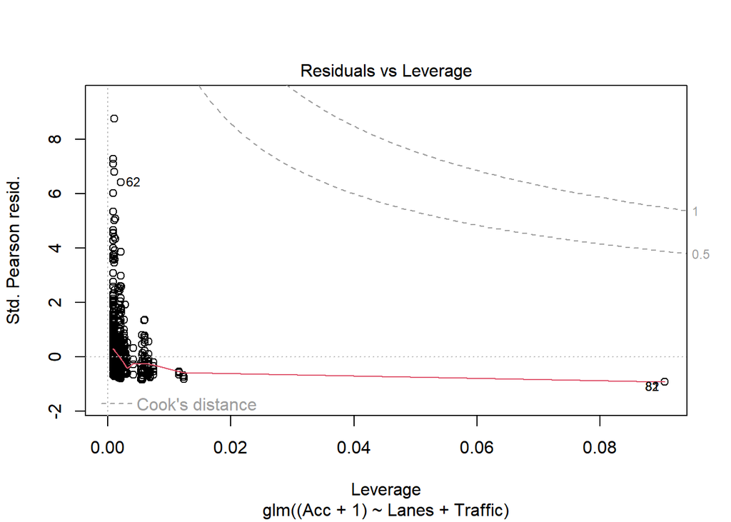

```
## [1] 5597.975
```

```
##
## Call:
## glm(formula = (Acc + 1) ~ Traffic, family = Gamma(link = "log"),
##     data = Accidents)
##
## Deviance Residuals:
##     Min       1Q   Median       3Q      Max
## -3.1813  -0.8433  -0.3690   0.1257   3.7825
##
## Coefficients:
##              Estimate Std. Error t value Pr(>|t|)
## (Intercept) 8.671e-01  4.050e-02   21.41   <2e-16 ***
## Traffic     5.989e-08  2.469e-09   24.25   <2e-16 ***
## ---
## Signif. codes:  0 '***' 0.001 '**' 0.01 '*' 0.05 '.' 0.1 ' ' 1
##
## (Dispersion parameter for Gamma family taken to be 1.246523)
##
##     Null deviance: 1360.37  on 1159  degrees of freedom
## Residual deviance:  895.83  on 1158  degrees of freedom
## AIC: 5599
##
## Number of Fisher Scoring iterations: 15
```

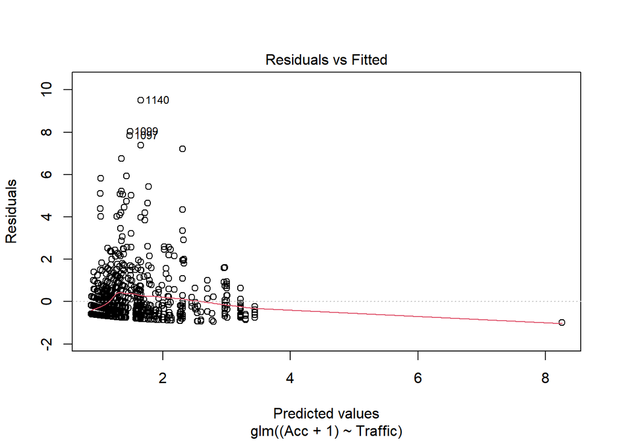

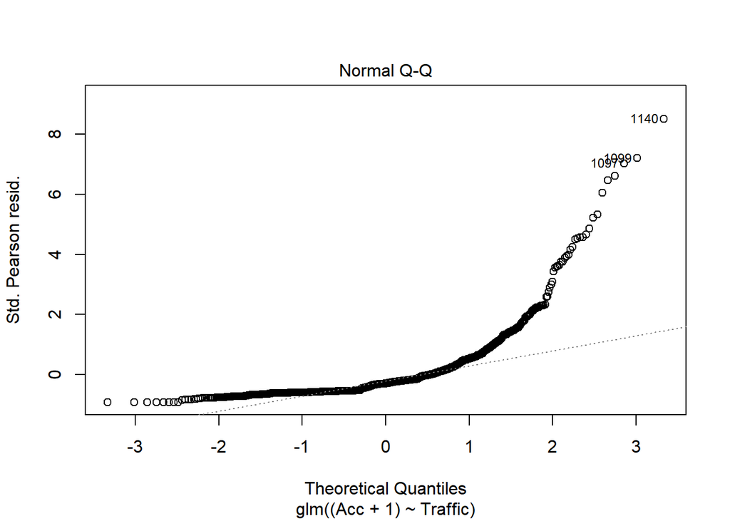

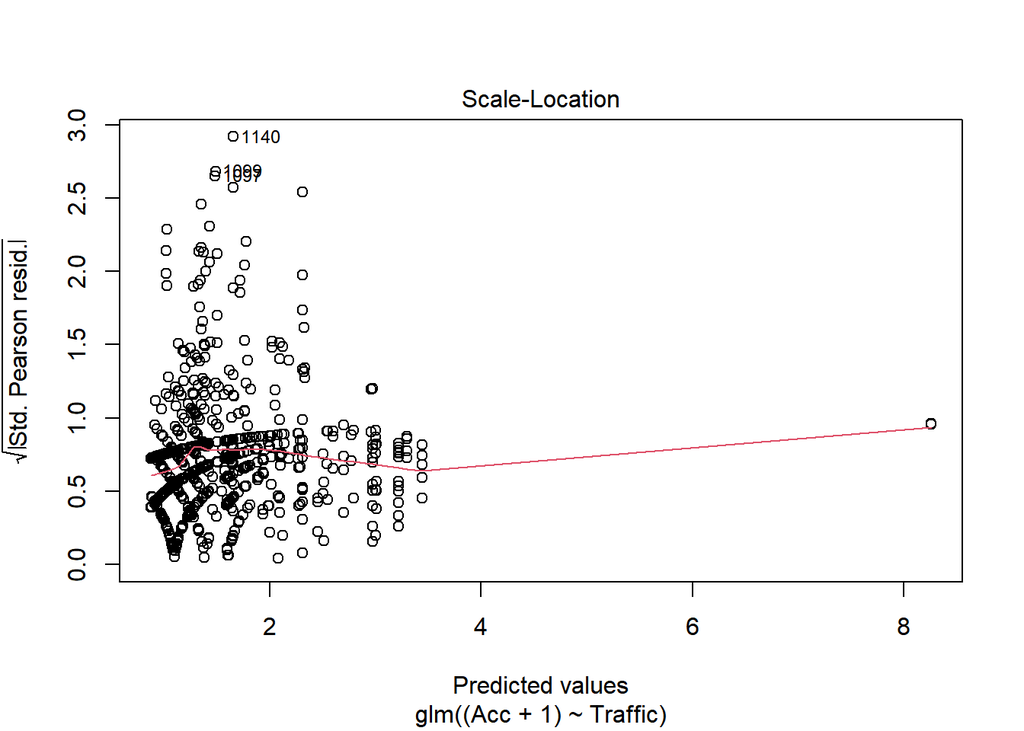

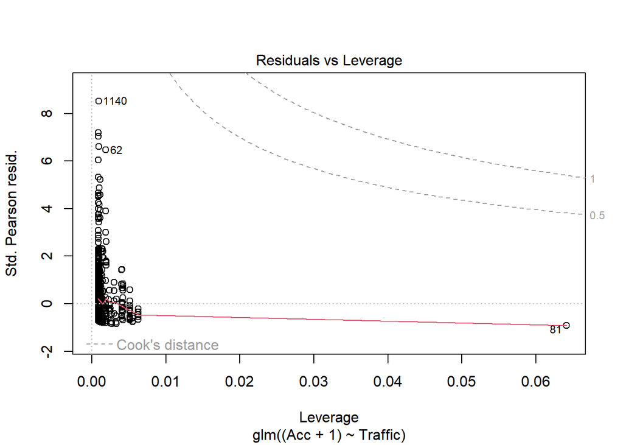

```
## [1] 5598.981
```

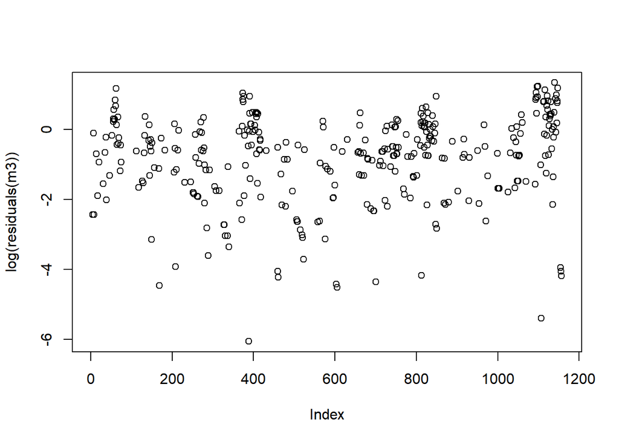

## AIC selection

```
## Start:  AIC=4698.81
## Acc ~ 1
##
##             Df Sum of Sq   RSS    AIC
## + Tunnel    91     48145 18368 3388.1
## + Company   24     25367 41146 4189.7
## + SlopeType  4     22808 43704 4219.7
## + Traffic    1     16047 50466 4380.5
## + Urban      1     12736 53777 4454.3
## + Lanes      1      7763 58750 4556.9
## + Limit      1      4566 61947 4618.3
## + HGV        1      3257 63256 4642.6
## + Type       1      2621 63892 4654.2
## + Width      1      2352 64161 4659.0
## + Year       1      1758 64755 4669.7
## + Length     1       368 66145 4694.4
## + Direction  1       115 66398 4698.8
## <none>                   66513 4698.8
## + Slope      1        86 66427 4699.3
##
## Step:  AIC=3388.13
## Acc ~ Tunnel
##
##             Df Sum of Sq   RSS    AIC
## + Lanes      1    57.537 18310 3386.5
## + Year       1    52.291 18316 3386.8
## + Slope      1    36.486 18331 3387.8
## <none>                   18368 3388.1
## + Direction  1    30.391 18337 3388.2
## + Length     1    19.156 18349 3388.9
## + Traffic    1    14.813 18353 3389.2
## + HGV        1    12.154 18356 3389.4
##
## Step:  AIC=3386.49
## Acc ~ Tunnel + Lanes
##
##             Df Sum of Sq   RSS    AIC
## + Year       1    52.291 18258 3385.2
## <none>                   18310 3386.5
## + Length     1    15.526 18295 3387.5
## + Traffic    1    14.813 18295 3387.5
## + Direction  1    13.720 18297 3387.6
## + HGV        1    12.154 18298 3387.7
## + Slope      1    11.771 18299 3387.7
##
## Step:  AIC=3385.17
## Acc ~ Tunnel + Lanes + Year
##
##             Df Sum of Sq   RSS    AIC
## <none>                   18258 3385.2
## + Length     1   14.6682 18243 3386.2
## + Direction  1   13.7205 18244 3386.3
## + Slope      1   11.7714 18246 3386.4
## + HGV        1    8.1133 18250 3386.7
## + Traffic    1    4.0500 18254 3386.9
```

```
## Start:  AIC=3391.56
## Acc ~ Year + Direction + Traffic + HGV + Slope + Urban + Type +
##     Length + Limit + SlopeType + Width + Lanes + Tunnel + Company
##
##
## Step:  AIC=3391.56
## Acc ~ Year + Direction + Traffic + HGV + Slope + Urban + Type +
##     Length + Limit + SlopeType + Width + Lanes + Tunnel
##
##
## Step:  AIC=3391.56
## Acc ~ Year + Direction + Traffic + HGV + Slope + Urban + Type +
##     Length + Limit + SlopeType + Lanes + Tunnel
##
##
## Step:  AIC=3391.56
## Acc ~ Year + Direction + Traffic + HGV + Slope + Urban + Type +
##     Length + Limit + Lanes + Tunnel
##
##
## Step:  AIC=3391.56
## Acc ~ Year + Direction + Traffic + HGV + Slope + Urban + Type +
##     Length + Lanes + Tunnel
##
##
## Step:  AIC=3391.56
## Acc ~ Year + Direction + Traffic + HGV + Slope + Urban + Length +
##     Lanes + Tunnel
##
##
## Step:  AIC=3391.56
## Acc ~ Year + Direction + Traffic + HGV + Slope + Length + Lanes +
##     Tunnel
##
##             Df Sum of Sq   RSS    AIC
## - Traffic    1       2.6 18204 3389.7
## - HGV        1       7.0 18208 3390.0
## - Slope      1      15.3 18216 3390.5
## - Lanes      1      16.7 18218 3390.6
## - Length     1      18.0 18219 3390.7
```

[output cut: 44 more lines]

```
##          Df Sum of Sq   RSS    AIC
## - Length  1        15 18258 3385.2
## <none>                18243 3386.2
## - Year    1        51 18295 3387.5
## - Lanes   1        54 18297 3387.7
## - Tunnel 91     38949 57193 4529.7
##
## Step:  AIC=3385.17
## Acc ~ Year + Lanes + Tunnel
##
##          Df Sum of Sq   RSS    AIC
## <none>                18258 3385.2
## - Year    1        52 18310 3386.5
## - Lanes   1        58 18315 3386.8
## - Tunnel 91     39410 57668 4537.3
```

```
## Start:  AIC=4698.81
## Acc ~ 1
##
##             Df Sum of Sq   RSS    AIC
## + Tunnel    91     48145 18368 3388.1
## + Company   24     25367 41146 4189.7
## + SlopeType  4     22808 43704 4219.7
## + Traffic    1     16047 50466 4380.5
## + Urban      1     12736 53777 4454.3
## + Lanes      1      7763 58750 4556.9
## + Limit      1      4566 61947 4618.3
## + HGV        1      3257 63256 4642.6
## + Type       1      2621 63892 4654.2
## + Width      1      2352 64161 4659.0
## + Year       1      1758 64755 4669.7
## + Length     1       368 66145 4694.4
## + Direction  1       115 66398 4698.8
## <none>                   66513 4698.8
## + Slope      1        86 66427 4699.3
##
## Step:  AIC=3388.13
## Acc ~ Tunnel
##
##             Df Sum of Sq   RSS    AIC
## + Lanes      1        58 18310 3386.5
## + Year       1        52 18315 3386.8
## + Slope      1        36 18331 3387.8
## <none>                   18368 3388.1
## + Direction  1        30 18337 3388.2
## + Length     1        19 18349 3388.9
## + Traffic    1        15 18353 3389.2
## + HGV        1        12 18356 3389.4
## - Tunnel    91     48145 66513 4698.8
##
## Step:  AIC=3386.49
## Acc ~ Tunnel + Lanes
##
##             Df Sum of Sq   RSS    AIC
## + Year       1        52 18258 3385.2
## <none>                   18310 3386.5
## + Length     1        16 18295 3387.5
## + Traffic    1        15 18295 3387.5
## + Direction  1        14 18297 3387.6
## + HGV        1        12 18298 3387.7
## + Slope      1        12 18298 3387.7
## - Lanes      1        58 18368 3388.1
## - Tunnel    91     40440 58750 4556.9
##
## Step:  AIC=3385.17
## Acc ~ Tunnel + Lanes + Year
##
##             Df Sum of Sq   RSS    AIC
## <none>                   18258 3385.2
## + Length     1        15 18243 3386.2
## + Direction  1        14 18244 3386.3
## + Slope      1        12 18246 3386.4
## - Year       1        52 18310 3386.5
## + HGV        1         8 18250 3386.7
## - Lanes      1        58 18315 3386.8
## + Traffic    1         4 18254 3386.9
## - Tunnel    91     39410 57668 4537.3
```

```
## [1] 6679.106
```

```
## [1] 7159.443
```

```
## [1] 6679.106
```

```
## [1] 7159.443
```

```
## [1] 6679.106
```

```
## [1] 7159.443
```

they all give the model fitted with tunnel, year and lanes. the AIC and BIC aren’t that different